# VECM

Dương Trung Sơn, Lê Trà My

October 24, 2016

# 1 Chu kỳ kinh tế và ảnh hưởng tới hoạt động ngân hàng

Một nghiên cứu của ECB (F.Boissay, F.Collard và F.Smets 2012) đã phát hiện 3 stylized facts về suy thoái kinh tế và khủng hoảng ngành ngân hàng tại các quốc gia phát triển:

- Suy thoái kinh tế xảy ra trung bình 10 năm 1 lần và khủng hoảng ngân hàng xảy ra trung bình 40 năm 1 lần
- Suy thoái kinh tế xảy ra cùng với khủng hoảng ngân hàng gây ra hậu quả lớn và lâu dài hơn so với suy thoái kinh tế đơn thuần
- Khủng hoảng ngành ngân hàng không xảy ra ngẫu nhiên mà thường ở thời kỳ bùng nổ tín dụng

Tại châu Á, một số đặc điểm nói trên có thể thấy tại cuộc khủng hoảng tài chính châu Á năm 1997.Khi đó nhiều quốc gia tại châu Á như Hàn Quốc, Hồng Kong, Thái Lan, Malaysia ở trong giai đoạn bùng nổ kinh tế, tín dụng tăng trưởng nóng và luồng vốn đầu tư nước ngoài chảy vào mạnh mẽ (hot money). Tốc độ tăng trưởng trung bình của các quốc gia này từ 8-12% trong giai đoạn 1980 đến 1993. Tuy nhiên, hệ thống tín dụng dựa trên mối quan hệ, chính sách của chính phủ và các cú sốc từ nền kinh tế Trung Quốc, Nhật Bản và Mỹ đã đẩy các nền kinh tế trên vào khủng hoảng.Tại Thái Lan, đồng Bath mất hơn 50% giá trị, thị trường chứng khoán giảm 75%, công ty tài chính lớn nhất Thái lan phá sản. Nợ xấu tại Hàn quốc tăng mạnh khiến 787 tổ chức tín dụng mất khả năng thanh toán, đồng won giảm gần 1 nửa giá trị.

Tại Việt Nam, hệ thống tài chính tương đối non trẻ, tuy nhiên cũng đã xảy ra 2 cuộc khủng hoảng đáng chú ý: Khủng hoảng quỹ tín dụng nhân dân (1990) và suy thoái kinh tế (2009-2013). Nguyên nhân gây ra suy thoái kinh tế Việt Nam có khá nhiều điểm tương đồng so với cuộc khủng hoảng tài chính châu Á nói trên. Tăng trưởng tín dụng liên tục ở mức cao, có thời điểm lên tới 50%; lạm phát tăng mạnh lên 2 con số; SBV phá giá liên tục (có thời điểm SBV phá giá 9.3% trong 1 ngày). Hoạt động ngân hàng bị ảnh hưởng nặng nề khi nợ xấu tăng cao, nhiều ngân hàng rơi vào tình trạng mất khả năng thanh toán….

Do đó, dự báo xu hướng kinh tế vĩ mô nói chung và khủng hoảng nói riêng sẽ giúp ngân hàng phòng tránh được những rủi ro lớn phát sinh, đồng thời đưa ra các kịch bản ứng phó phù hợp.

[figure not shown]

# 2 Mô hình dự báo & phân tích kinh tế vĩ mô

## 2.1 Cơ sở lý luận chung về dự báo & phân tích kinh tế vĩ mô

Dự báo dựa trên phân tích hồi quy. Mô hình dự báo chuỗi thời gian sẽ giúp dự báo các giá trị tương lai về một đối tượng dự báo nào đó trên nền tảng xu hướng vận động của chính chuỗi dữ liệu đó trong quá khứ và hiện tại. Tuy nhiên, các biến kinh tế thường có các mối quan hệ với nhau, và dựa trên các mối quan hệ đó mà chúng ta có thể suy luận được hành vi của một biến số nào đó khi đã có thông tin từ các biến số khác có liên quan.

Các nhà hoạch định chính sách vĩ mô có thể dự báo được tốc độ tăng trưởng kinh tế trên cơ sở dự đoán được các thông tin tương lai về cung tiền, lãi suất, hay chi tiêu công. Hoặc các nhà nghiên cứu có thể dự đoán được mức độ chi tiêu của dân cư cho một nhóm hàng hóa nào đó trên cơ sở dự đoán xu hướng gia tăng trong thu nhập và trình độ học vấn. Để có thể làm được như vậy, các phương pháp phân tích hồi quy trở thành một trong những công cụ vô cùng hữu ích. Ngoài ra, phân tích hồi quy còn giúp những người nghiên cứu kiểm chứng nhiều giả thiết kinh tế quan trọng nhằm có thêm thông tin chắc chắn cho việc ra quyết định về chính sách hay giải pháp nào đó.

Có nhiều mô hình tích hợp được sử dụng trong ước lượng & dự báo các biến số kinh tế (ARIMA, VAR, VECM…)

### 2.1.1 Mô hình ARIMA

Là phương pháp dự báo yếu tố nghiên cứu một cách độc lập ( dự báo theo chuỗi thời gian). Bằng các thuật toán sử dụng độ trễ sẽ đưa ra mô hình dự báo thích hợp. Mô hình ARIMA có tên gọi Mô hình tự hồi quy trung bình trượt. Mô hình này lần đầu tiên được đưa ra bởi Box & Jenkins (1970). ARIMA được kết hợp bởi 3 thành thành phần chính: AR (thành phần tự hồi quy), I (tính dừng của chuỗi thời gian) và MA (thành phần trung bình trượt). Để ước lượng mô hình ARIMA cần 4 buớc: nhận dạng mô hình, uớc luợng, kiểm dịnh, và dự báo. Tuy nhiên, mô hình ARIMA chỉ tiến hành phân tích trên một chuỗi thời gian (1 biến & dữ liệu quá khứ của nó).

### 2.1.2 Mô hình VAR

Mô hình VAR (Mô hình tự hồi quy vector) được nhà khoa học kinh tế Mỹ là Chrishtopher Sims đề xuất vào năm 1980. Về bản chất, VAR là kết hợp của 2 phương pháp: tự hồi quy đơn chiều (AR) và hệ phương trình ngẫu nhiên (Ses). VAR tổng hợp được ưu điểm của 2 phương pháp trên, đó là rất dễ ước lượng bằng phương pháp tối thiểu hóa phần dư (OLS) và ước lượng nhiều biến trong cùng 1 hệ thống. Đồng thời nó khắc phục được nhược điểm là không quan tâm đến tính nội sinh khi tác động qua lại lẫn nhau của các biến kinh tế. Điều này làm cho phương pháp cổ điển hồi quy bội hồi 1 phương trình hồi quy đôi khi bị sai lệch ước lượng. Đây là lý do cơ bản khiến VAR trở nên phổ biến trong nghiên cứu kinh tế vĩ mô.

Với K biến, mô hình VAR bậc p có dạng phương trình sau:

$y_{t}=A_{1}y_{t-1} +...+ A_{p}y_{t-p}+u_{t}$

Trong đó $A_{i}$ là ma trận hệ số (KxK) và $u_{t}=(u_{1t}...,u_{Kt})$

### 2.1.3 Mô hình VECM

Mô hình VECM là một dạng của mô hình VAR tổng quát, được sử dụng trong trường hợp chuỗi dữ liệu là không dừng và chứa đựng mối quan hệ đồng kết hợp. Mô hình VECM là phù hợp khi chúng ta có nhiều chuỗi thời gian khác nhau và cần phải xem xét mối quan hệ, tác động qua lại giữa chúng.

- Tính dừng (stationary)

Để dự báo chính xác, chuỗi thời gian phải có tính dừng. Một chuỗi thời gian là dừng nếu trung bình, phương sai và tự đồng phương sai (tại các độ trễ khác nhau) sẽ giữ nguyên không đổi dù cho chúng được xác định vào thời điểm nào đi nữa. Tuy nhiên hầu hết các biến kinh tế là những chuỗi thời gian không có tính dừng. Để chuyển thành chuỗi dừng, phải dùng kỹ thuật sai phân. Ngoài ra, mô hình VECM sẽ giải quyết vấn đề này mà không cần sai phân dữ liệu.

- Đồng kết hợp (cointegration)

Đồng kết hợp (Đồng tích hợp) là khái niệm cơ bản của kinh tế lượng hiện đại, là một khái niệm cơ bản của kinh tế học và mô hình hóa tài chính, phân tích chuỗi. Theo nghiên cứu nổi tiếng của Engle và Granger (1986), khi xét mô hình có nhiều biến số theo chuỗi thời gian, cũng có nhiều trường hợp, mặc dù các biến số là không dừng, nhưng khi thực hiện phép hồi quy hay tổ hợp tuyến tính của các biến này vẫn cho nhiễu trắng (được một chuỗi dừng). Trong trường hợp này, mô hình vẫn có thể ước lượng được mà không bị hiện tượng hồi quy giả mạo và mối quan hệ giữa các biến được gọi là quan hệ đồng tích hợp (Cointegrating relationships).

Mô hình VECM có phương trình như sau:

$\Delta y_{t}= \Pi y_{t-1} + \Gamma_{1}\Delta y_{t-1} +...+\Gamma_{p-1}\Delta y_{t-p+1} + u_{t}$

Trong đó $\Pi=-(I_{K}-A_{1}-...-A_{p})$ và $\Gamma=-(A_{i+1}+...+A_{p})$ với $i=1,...,p-1$

### 2.1.4 Hàm phản ứng đẩy (Impulse Response Function)

Hàm phản ứng đẩy IRF cho chúng ta biết được có hay không sự ảnh hưởng của cú sốc đến các biến còn lại. Khác biệt giữa dự báo và kết quả (lỗi dự báo) đối với một biến cụ thể được coi là một loại “cú sốc” Ví dụ như lãi suất bất ngờ thay đổi có thể là phản ứng trước một cú sốc khác, ví dụ như thất nghiệp hay lạm phát, cũng có thể chúng xảy ra hoàn toàn “độc lập”. Sự thay đổi một cách độc lập ấy được gọi là “cú sốc cơ bản”. Phân tích “phản ứng đẩy” minh họa tác động của các cú sốc cơ bản đối với các biến số vĩ mô qua thời gian. Phân tích “phản ứng đẩy” giúp chúng ta hiểu thêm về kinh tế vĩ mô và đã có những ảnh hưởng to lớn tới việc thi hành chính sách tiền tệ. VÍ dụ, việc một NHTW có lạm phát mục tiêu điều chỉnh lãi suất để đạt tới mức mục tiêu đó trong vòng 1-2 năm đã là chuyện bình thường. Chính sách tiền tệ thắt chặt đồng nghĩa với việc 1-2 năm sau lạm phát mới thấp còn GDP giảm ngay lập tức.

Hàm IRF có phương trình như sau:

$y_{t} = \Psi_{0}\epsilon_{t} + \Psi_{1}\epsilon_{t-1} + ...$

Trong đó: $\Psi_{i} = \Phi_{i}B$ (i=0,1,2,…)

## 2.2 Xây dựng mô hình

### 2.2.1 Cơ sở lý thuyết mô hình

Mô hình dự báo dựa trên mô hình lạm phát đối với các quốc gia nhỏ (Inflation Dynamics and Monetary transmission in Vietnam and Emerging Asia - IMF 2013), phương trình như sau:

$\Delta p_{t} = \kappa_{1}\Delta\epsilon_{t} + \kappa_{2}\Delta p_{t}^W + \kappa_{3}\Delta M_{t} + \kappa_{4}\Delta Y_{t} + \kappa_{5}\Delta r_{t} + \zeta_{t}$

Trong đó:

- $p$: Chỉ số giá tiêu dùng
- $\epsilon$ : Tỷ giá danh nghĩa
- $p^W$ : Giá hàng hóa thế giới
- $M$ : Cung tiền
- $Y$ : GDP
- $r$ : Lãi suất danh nghĩa

Mặc dù mô hình trên được sử dụng để phân tích các nhân tố tác động đến lạm phát, các biến số kinh tế vĩ mô có tác động qua lại với nhau. Do đó, mô hình trên cũng có thể được dùng để phân tích và dự báo lãi suất, tỷ giá và tăng trưởng kinh tế.

### 2.2.2 Dữ liệu ước lượng mô hình

Dữ liệu sử dụng để ước lượng mô hình bắt đầu từ 2000Q1 đến 2016Q3, các biến trong mô hình bao gồm:

- GDP
- Chỉ số giá tiêu dùng CPI
- Tín dụng đối với nền kinh tế (sử dụng thay thế cung tiền)
- Lãi suất tiền gửi và lãi suất cho vay thị trường 1
- Tỷ giá danh nghĩa đa phương (NEER)
- Giá dầu giao ngay, đại diện cho biến giá hàng hóa thế giới

Nguồn dữ liệu GDP được lấy từ Tổng cục Thống kê (GSO), các dữ liệu còn lại được lấy từ IFS, DOTS database của IMF. Dữ liệu GDP giai đoạn 2000-2012 có năm gốc là 1994 được chuyển sang năm gốc 2010 dựa trên số liệu tăng trưởng GDP trong quá khứ.

Tỷ giá danh nghĩa đa phương (NEER) được tác giả tính toán dựa trên bình quân hình học, tỷ trọng của các đồng tiền bằng tỷ lệ giao dịch thương mại của Việt Nam với 8 quốc gia, vùng lãnh thổ : Hoa Kỳ, Trung Quốc, EU, Nhật Bản, Hàn Quốc, Singapore , Thái Lan và Đài Loan.

Kiểm định tính dừng(stationary) của chuỗi dữ liệu bằng Augmented Dickey-Fuller test:

| Variable | ADF | p-value |
| --- | --- | --- |
| GDP | -0.7562 | 0.9608 |
| CPI | -1.9737 | 0.5858 |
| Credit | -0.6351 | 0.9713 |
| Deposit_rate | -1.1042 | 0.9149 |
| Lending_rate | -0.8989 | 0.9470 |
| Exchange_rate | -1.2675 | 0.8724 |
| oil | -0.6559 | 0.9695 |

Các chuỗi dữ liệu khi kiểm định đều có p-value lớn hơn 0.01(tương ứng với độ tin cậy 99%), do ta không thể bác bỏ giả thuyết H0(chuỗi dữ liệu không có tính dừng).

Kiểm định tính đồng liên kết trong chuỗi dữ liệu bằng Johansen test:

|  | trace_test | 10pct | 5pct | 1pct |
| --- | --- | --- | --- | --- |
| r <= 6 \| | 10.23 | 10.49 | 12.25 | 16.26 |
| r <= 5 \| | 32.20 | 22.76 | 25.32 | 30.45 |
| r <= 4 \| | 56.05 | 39.06 | 42.44 | 48.45 |
| r <= 3 \| | 83.86 | 59.14 | 62.99 | 70.05 |
| r <= 2 \| | 128.07 | 83.20 | 87.31 | 96.58 |
| r <= 1 \| | 186.17 | 110.42 | 114.90 | 124.75 |
| r = 0 \| | 276.41 | 141.01 | 146.76 | 158.49 |

Mô hình ước lượng nhiều biến, chuỗi dữ liệu là không dừng và đồng liên kết. Như vậy, mô hình VECM là phù hợp khi chúng ta có nhiều chuỗi thời gian khác nhau và cần phải xem xét mối quan hệ, tác động qua lại giữa chúng.

### 2.2.3 Ước lượng mô hình

- **Response GDP.d**:

  |  | Estimate | Std. Error | t value | Pr(>\|t\|) |
  | --- | --- | --- | --- | --- |
  | **ect2** | -0.009074 | 0.02071 | -0.4381 | 0.6639 |
  | **constant** | 1.158 | 1.582 | 0.7319 | 0.469 |
  | **sd1** | -0.08248 | 0.08804 | -0.9369 | 0.3551 |
  | **sd2** | -0.002194 | 0.01765 | -0.1243 | 0.9018 |
  | **sd3** | -0.05078 | 0.0928 | -0.5472 | 0.5876 |
  | **GDP.dl1** | -0.8464 | 0.1202 | -7.039 | 2.916e-08 |
  | **CPI.dl1** | 0.1218 | 0.2038 | 0.5976 | 0.5539 |
  | **Credit.dl1** | 0.08547 | 0.09509 | 0.8989 | 0.3747 |
  | **Deposit_rate.dl1** | -0.003022 | 0.02586 | -0.1169 | 0.9076 |
  | **Lending_rate.dl1** | 0.02639 | 0.04835 | 0.5458 | 0.5885 |
  | **Exchange_rate.dl1** | -0.2123 | 0.118 | -1.8 | 0.08031 |
  | **oil.dl1** | 0.02367 | 0.02032 | 1.165 | 0.2516 |
  | **GDP.dl2** | -0.9243 | 0.06844 | -13.51 | 1.159e-15 |
  | **CPI.dl2** | -0.5127 | 0.2734 | -1.875 | 0.06893 |
  | **Credit.dl2** | 0.08663 | 0.09513 | 0.9106 | 0.3685 |
  | **Deposit_rate.dl2** | -0.0359 | 0.03132 | -1.146 | 0.2592 |
  | **Lending_rate.dl2** | 0.05018 | 0.04728 | 1.061 | 0.2956 |
  | **Exchange_rate.dl2** | -0.2057 | 0.1137 | -1.81 | 0.07869 |
  | **oil.dl2** | 0.02706 | 0.0171 | 1.583 | 0.1223 |
  | **GDP.dl3** | -0.8923 | 0.1036 | -8.61 | 2.888e-10 |
  | **CPI.dl3** | -0.1091 | 0.2135 | -0.5111 | 0.6124 |
  | **Credit.dl3** | -0.06498 | 0.09255 | -0.7021 | 0.4871 |
  | **Deposit_rate.dl3** | -0.01777 | 0.02723 | -0.6523 | 0.5183 |
  | **Lending_rate.dl3** | 0.0375 | 0.04521 | 0.8294 | 0.4123 |
  | **Exchange_rate.dl3** | -0.2182 | 0.1127 | -1.935 | 0.06087 |
  | **oil.dl3** | 0.01302 | 0.01691 | 0.7702 | 0.4462 |
  | **ect1** | -0.05098 | 0.1058 | -0.4819 | 0.6328 |

  Fitting linear model: GDP.d ~ ect1 + ect2 + constant + sd1 + sd2 + sd3 + GDP.dl1 + CPI.dl1 + Credit.dl1 + Deposit_rate.dl1 + Lending_rate.dl1 + Exchange_rate.dl1 + oil.dl1 + GDP.dl2 + CPI.dl2 + Credit.dl2 + Deposit_rate.dl2 + Lending_rate.dl2 + Exchange_rate.dl2 + oil.dl2 + GDP.dl3 + CPI.dl3 + Credit.dl3 + Deposit_rate.dl3 + Lending_rate.dl3 + Exchange_rate.dl3 + oil.dl3 - 1

  | Observations | Residual Std. Error | $R^2$ | Adjusted $R^2$ |
  | --- | --- | --- | --- |
  | 63 | 0.01153 | 0.9989 | 0.9981 |

- **Response CPI.d**:

  |  | Estimate | Std. Error | t value | Pr(>\|t\|) |
  | --- | --- | --- | --- | --- |
  | **ect2** | -0.04978 | 0.01625 | -3.063 | 0.004128 |
  | **constant** | 3.263 | 1.241 | 2.629 | 0.01252 |
  | **sd1** | 0.09691 | 0.06907 | 1.403 | 0.1692 |
  | **sd2** | -0.04342 | 0.01385 | -3.135 | 0.003412 |
  | **sd3** | 0.0769 | 0.07281 | 1.056 | 0.2979 |
  | **GDP.dl1** | 0.004735 | 0.09434 | 0.05019 | 0.9602 |
  | **CPI.dl1** | 0.615 | 0.1599 | 3.846 | 0.0004719 |
  | **Credit.dl1** | 0.2424 | 0.07461 | 3.249 | 0.002511 |
  | **Deposit_rate.dl1** | 0.01201 | 0.02029 | 0.5918 | 0.5577 |
  | **Lending_rate.dl1** | -0.07473 | 0.03794 | -1.97 | 0.05659 |
  | **Exchange_rate.dl1** | 0.2965 | 0.09255 | 3.204 | 0.002839 |
  | **oil.dl1** | -0.02342 | 0.01594 | -1.469 | 0.1505 |
  | **GDP.dl2** | 0.07133 | 0.0537 | 1.328 | 0.1924 |
  | **CPI.dl2** | 0.003685 | 0.2145 | 0.01718 | 0.9864 |
  | **Credit.dl2** | 0.1894 | 0.07464 | 2.538 | 0.01564 |
  | **Deposit_rate.dl2** | 0.01015 | 0.02457 | 0.4133 | 0.6819 |
  | **Lending_rate.dl2** | 0.003848 | 0.03709 | 0.1037 | 0.918 |
  | **Exchange_rate.dl2** | 0.2393 | 0.08918 | 2.684 | 0.01093 |
  | **oil.dl2** | -0.01853 | 0.01342 | -1.381 | 0.1758 |
  | **GDP.dl3** | -0.05923 | 0.08131 | -0.7284 | 0.4711 |
  | **CPI.dl3** | -0.2968 | 0.1675 | -1.772 | 0.0848 |
  | **Credit.dl3** | 0.1453 | 0.07262 | 2 | 0.05306 |
  | **Deposit_rate.dl3** | 0.0214 | 0.02137 | 1.001 | 0.3233 |
  | **Lending_rate.dl3** | 0.003078 | 0.03547 | 0.08677 | 0.9313 |
  | **Exchange_rate.dl3** | 0.1137 | 0.08846 | 1.286 | 0.2068 |
  | **oil.dl3** | 0.003072 | 0.01327 | 0.2316 | 0.8182 |
  | **ect1** | -0.2483 | 0.083 | -2.991 | 0.004993 |

  Fitting linear model: CPI.d ~ ect1 + ect2 + constant + sd1 + sd2 + sd3 + GDP.dl1 + CPI.dl1 + Credit.dl1 + Deposit_rate.dl1 + Lending_rate.dl1 + Exchange_rate.dl1 + oil.dl1 + GDP.dl2 + CPI.dl2 + Credit.dl2 + Deposit_rate.dl2 + Lending_rate.dl2 + Exchange_rate.dl2 + oil.dl2 + GDP.dl3 + CPI.dl3 + Credit.dl3 + Deposit_rate.dl3 + Lending_rate.dl3 + Exchange_rate.dl3 + oil.dl3 - 1

  | Observations | Residual Std. Error | $R^2$ | Adjusted $R^2$ |
  | --- | --- | --- | --- |
  | 63 | 0.009046 | 0.9328 | 0.8823 |

- **Response Credit.d**:

  |  | Estimate | Std. Error | t value | Pr(>\|t\|) |
  | --- | --- | --- | --- | --- |
  | **ect2** | 0.007528 | 0.03736 | 0.2015 | 0.8414 |
  | **constant** | 0.5498 | 2.853 | 0.1927 | 0.8483 |
  | **sd1** | -0.01294 | 0.1588 | -0.0815 | 0.9355 |
  | **sd2** | -0.008322 | 0.03184 | -0.2614 | 0.7953 |
  | **sd3** | 0.002967 | 0.1674 | 0.01773 | 0.986 |
  | **GDP.dl1** | -0.0213 | 0.2169 | -0.09819 | 0.9223 |
  | **CPI.dl1** | 0.201 | 0.3677 | 0.5468 | 0.5879 |
  | **Credit.dl1** | 0.4592 | 0.1715 | 2.677 | 0.0111 |
  | **Deposit_rate.dl1** | -0.1187 | 0.04664 | -2.545 | 0.01536 |
  | **Lending_rate.dl1** | 0.02666 | 0.08722 | 0.3056 | 0.7616 |
  | **Exchange_rate.dl1** | -0.5132 | 0.2128 | -2.412 | 0.0211 |
  | **oil.dl1** | 0.1003 | 0.03665 | 2.736 | 0.009596 |
  | **GDP.dl2** | 0.0344 | 0.1234 | 0.2786 | 0.7821 |
  | **CPI.dl2** | -0.2538 | 0.4932 | -0.5145 | 0.61 |
  | **Credit.dl2** | 0.03172 | 0.1716 | 0.1849 | 0.8544 |
  | **Deposit_rate.dl2** | -0.1024 | 0.05649 | -1.813 | 0.0782 |
  | **Lending_rate.dl2** | 0.1444 | 0.08528 | 1.693 | 0.09914 |
  | **Exchange_rate.dl2** | -0.6141 | 0.205 | -2.995 | 0.004938 |
  | **oil.dl2** | 0.008419 | 0.03085 | 0.2729 | 0.7865 |
  | **GDP.dl3** | -0.04758 | 0.1869 | -0.2545 | 0.8005 |
  | **CPI.dl3** | -0.09923 | 0.385 | -0.2577 | 0.7981 |
  | **Credit.dl3** | 0.02758 | 0.1669 | 0.1652 | 0.8697 |
  | **Deposit_rate.dl3** | 0.03668 | 0.04912 | 0.7467 | 0.4601 |
  | **Lending_rate.dl3** | -0.009789 | 0.08155 | -0.12 | 0.9051 |
  | **Exchange_rate.dl3** | -0.4197 | 0.2034 | -2.064 | 0.04628 |
  | **oil.dl3** | -0.03335 | 0.0305 | -1.093 | 0.2815 |
  | **ect1** | 0.02584 | 0.1908 | 0.1354 | 0.893 |

  Fitting linear model: Credit.d ~ ect1 + ect2 + constant + sd1 + sd2 + sd3 + GDP.dl1 + CPI.dl1 + Credit.dl1 + Deposit_rate.dl1 + Lending_rate.dl1 + Exchange_rate.dl1 + oil.dl1 + GDP.dl2 + CPI.dl2 + Credit.dl2 + Deposit_rate.dl2 + Lending_rate.dl2 + Exchange_rate.dl2 + oil.dl2 + GDP.dl3 + CPI.dl3 + Credit.dl3 + Deposit_rate.dl3 + Lending_rate.dl3 + Exchange_rate.dl3 + oil.dl3 - 1

  | Observations | Residual Std. Error | $R^2$ | Adjusted $R^2$ |
  | --- | --- | --- | --- |
  | 63 | 0.0208 | 0.9458 | 0.9051 |

- **Response Deposit_rate.d**:

  |  | Estimate | Std. Error | t value | Pr(>\|t\|) |
  | --- | --- | --- | --- | --- |
  | **ect2** | 0.4053 | 0.1272 | 3.188 | 0.002963 |
  | **constant** | -33.04 | 9.712 | -3.402 | 0.001651 |
  | **sd1** | 0.8608 | 0.5405 | 1.593 | 0.12 |
  | **sd2** | -0.01905 | 0.1084 | -0.1758 | 0.8615 |
  | **sd3** | 1.052 | 0.5697 | 1.847 | 0.07305 |
  | **GDP.dl1** | -2.521 | 0.7382 | -3.415 | 0.001595 |
  | **CPI.dl1** | 3.64 | 1.251 | 2.909 | 0.006183 |
  | **Credit.dl1** | 0.2223 | 0.5838 | 0.3808 | 0.7056 |
  | **Deposit_rate.dl1** | 0.4415 | 0.1587 | 2.781 | 0.008563 |
  | **Lending_rate.dl1** | 0.003645 | 0.2969 | 0.01228 | 0.9903 |
  | **Exchange_rate.dl1** | 1.898 | 0.7242 | 2.621 | 0.01276 |
  | **oil.dl1** | 0.00841 | 0.1248 | 0.06742 | 0.9466 |
  | **GDP.dl2** | -0.7461 | 0.4202 | -1.776 | 0.08422 |
  | **CPI.dl2** | -3.393 | 1.679 | -2.021 | 0.05077 |
  | **Credit.dl2** | -0.4435 | 0.5841 | -0.7594 | 0.4526 |
  | **Deposit_rate.dl2** | -0.1183 | 0.1923 | -0.6154 | 0.5422 |
  | **Lending_rate.dl2** | 0.138 | 0.2903 | 0.4754 | 0.6373 |
  | **Exchange_rate.dl2** | 1.737 | 0.6978 | 2.489 | 0.01757 |
  | **oil.dl2** | -0.1233 | 0.105 | -1.175 | 0.2479 |
  | **GDP.dl3** | -1.474 | 0.6362 | -2.316 | 0.02635 |
  | **CPI.dl3** | 1.065 | 1.311 | 0.813 | 0.4216 |
  | **Credit.dl3** | 0.5343 | 0.5682 | 0.9403 | 0.3534 |
  | **Deposit_rate.dl3** | 0.01655 | 0.1672 | 0.09897 | 0.9217 |
  | **Lending_rate.dl3** | 0.08167 | 0.2776 | 0.2942 | 0.7703 |
  | **Exchange_rate.dl3** | 0.4919 | 0.6922 | 0.7107 | 0.4819 |
  | **oil.dl3** | 0.1505 | 0.1038 | 1.45 | 0.1558 |
  | **ect1** | 2.094 | 0.6495 | 3.225 | 0.002681 |

  Fitting linear model: Deposit_rate.d ~ ect1 + ect2 + constant + sd1 + sd2 + sd3 + GDP.dl1 + CPI.dl1 + Credit.dl1 + Deposit_rate.dl1 + Lending_rate.dl1 + Exchange_rate.dl1 + oil.dl1 + GDP.dl2 + CPI.dl2 + Credit.dl2 + Deposit_rate.dl2 + Lending_rate.dl2 + Exchange_rate.dl2 + oil.dl2 + GDP.dl3 + CPI.dl3 + Credit.dl3 + Deposit_rate.dl3 + Lending_rate.dl3 + Exchange_rate.dl3 + oil.dl3 - 1

  | Observations | Residual Std. Error | $R^2$ | Adjusted $R^2$ |
  | --- | --- | --- | --- |
  | 63 | 0.07078 | 0.8296 | 0.7018 |

- **Response Lending_rate.d**:

  |  | Estimate | Std. Error | t value | Pr(>\|t\|) |
  | --- | --- | --- | --- | --- |
  | **ect2** | -0.1448 | 0.1029 | -1.407 | 0.168 |
  | **constant** | 9.413 | 7.859 | 1.198 | 0.2389 |
  | **sd1** | 0.7599 | 0.4374 | 1.737 | 0.09088 |
  | **sd2** | -0.04286 | 0.08769 | -0.4888 | 0.628 |
  | **sd3** | 0.951 | 0.461 | 2.063 | 0.04641 |
  | **GDP.dl1** | -0.3127 | 0.5974 | -0.5235 | 0.6038 |
  | **CPI.dl1** | 2.739 | 1.013 | 2.704 | 0.01039 |
  | **Credit.dl1** | 0.7923 | 0.4724 | 1.677 | 0.1022 |
  | **Deposit_rate.dl1** | 0.2668 | 0.1285 | 2.077 | 0.04501 |
  | **Lending_rate.dl1** | -0.1247 | 0.2402 | -0.5192 | 0.6068 |
  | **Exchange_rate.dl1** | 0.9725 | 0.586 | 1.659 | 0.1057 |
  | **oil.dl1** | -0.0334 | 0.101 | -0.3309 | 0.7427 |
  | **GDP.dl2** | 0.682 | 0.34 | 2.006 | 0.05245 |
  | **CPI.dl2** | -3.42 | 1.358 | -2.517 | 0.01641 |
  | **Credit.dl2** | 0.5229 | 0.4727 | 1.106 | 0.2759 |
  | **Deposit_rate.dl2** | -0.1009 | 0.1556 | -0.6483 | 0.5209 |
  | **Lending_rate.dl2** | -0.07936 | 0.2349 | -0.3379 | 0.7374 |
  | **Exchange_rate.dl2** | 0.654 | 0.5647 | 1.158 | 0.2544 |
  | **oil.dl2** | -0.06935 | 0.08496 | -0.8163 | 0.4197 |
  | **GDP.dl3** | -0.6336 | 0.5149 | -1.231 | 0.2264 |
  | **CPI.dl3** | -0.4279 | 1.061 | -0.4035 | 0.689 |
  | **Credit.dl3** | 0.8885 | 0.4598 | 1.932 | 0.06123 |
  | **Deposit_rate.dl3** | 0.01464 | 0.1353 | 0.1082 | 0.9144 |
  | **Lending_rate.dl3** | 0.05701 | 0.2246 | 0.2538 | 0.8011 |
  | **Exchange_rate.dl3** | 0.09962 | 0.5601 | 0.1779 | 0.8598 |
  | **oil.dl3** | 0.1114 | 0.08401 | 1.326 | 0.1931 |
  | **ect1** | -0.7217 | 0.5256 | -1.373 | 0.1782 |

  Fitting linear model: Lending_rate.d ~ ect1 + ect2 + constant + sd1 + sd2 + sd3 + GDP.dl1 + CPI.dl1 + Credit.dl1 + Deposit_rate.dl1 + Lending_rate.dl1 + Exchange_rate.dl1 + oil.dl1 + GDP.dl2 + CPI.dl2 + Credit.dl2 + Deposit_rate.dl2 + Lending_rate.dl2 + Exchange_rate.dl2 + oil.dl2 + GDP.dl3 + CPI.dl3 + Credit.dl3 + Deposit_rate.dl3 + Lending_rate.dl3 + Exchange_rate.dl3 + oil.dl3 - 1

  | Observations | Residual Std. Error | $R^2$ | Adjusted $R^2$ |
  | --- | --- | --- | --- |
  | 63 | 0.05728 | 0.8065 | 0.6614 |

- **Response Exchange_rate.d**:

  |  | Estimate | Std. Error | t value | Pr(>\|t\|) |
  | --- | --- | --- | --- | --- |
  | **ect2** | -0.07583 | 0.04785 | -1.585 | 0.1218 |
  | **constant** | 6.067 | 3.655 | 1.66 | 0.1056 |
  | **sd1** | 0.003755 | 0.2034 | 0.01846 | 0.9854 |
  | **sd2** | 0.004537 | 0.04078 | 0.1113 | 0.912 |
  | **sd3** | 0.03397 | 0.2144 | 0.1584 | 0.875 |
  | **GDP.dl1** | 0.2729 | 0.2778 | 0.9825 | 0.3324 |
  | **CPI.dl1** | -0.2121 | 0.471 | -0.4504 | 0.6551 |
  | **Credit.dl1** | 0.4858 | 0.2197 | 2.211 | 0.03347 |
  | **Deposit_rate.dl1** | -0.05895 | 0.05974 | -0.9867 | 0.3304 |
  | **Lending_rate.dl1** | -0.04865 | 0.1117 | -0.4355 | 0.6658 |
  | **Exchange_rate.dl1** | -0.3563 | 0.2725 | -1.307 | 0.1994 |
  | **oil.dl1** | 0.1134 | 0.04695 | 2.415 | 0.02094 |
  | **GDP.dl2** | 0.263 | 0.1581 | 1.663 | 0.105 |
  | **CPI.dl2** | 0.2222 | 0.6318 | 0.3517 | 0.7271 |
  | **Credit.dl2** | -0.01724 | 0.2198 | -0.07841 | 0.9379 |
  | **Deposit_rate.dl2** | -0.05121 | 0.07236 | -0.7078 | 0.4837 |
  | **Lending_rate.dl2** | 0.07446 | 0.1092 | 0.6816 | 0.4998 |
  | **Exchange_rate.dl2** | -0.4156 | 0.2626 | -1.583 | 0.1223 |
  | **oil.dl2** | -0.05556 | 0.03951 | -1.406 | 0.1683 |
  | **GDP.dl3** | 0.1128 | 0.2394 | 0.4712 | 0.6403 |
  | **CPI.dl3** | -0.3245 | 0.4932 | -0.658 | 0.5147 |
  | **Credit.dl3** | -0.09377 | 0.2138 | -0.4385 | 0.6636 |
  | **Deposit_rate.dl3** | 0.1195 | 0.06292 | 1.9 | 0.06551 |
  | **Lending_rate.dl3** | -0.2098 | 0.1045 | -2.008 | 0.05214 |
  | **Exchange_rate.dl3** | -0.1639 | 0.2605 | -0.6291 | 0.5333 |
  | **oil.dl3** | 0.0425 | 0.03907 | 1.088 | 0.2839 |
  | **ect1** | -0.3908 | 0.2444 | -1.599 | 0.1186 |

  Fitting linear model: Exchange_rate.d ~ ect1 + ect2 + constant + sd1 + sd2 + sd3 + GDP.dl1 + CPI.dl1 + Credit.dl1 + Deposit_rate.dl1 + Lending_rate.dl1 + Exchange_rate.dl1 + oil.dl1 + GDP.dl2 + CPI.dl2 + Credit.dl2 + Deposit_rate.dl2 + Lending_rate.dl2 + Exchange_rate.dl2 + oil.dl2 + GDP.dl3 + CPI.dl3 + Credit.dl3 + Deposit_rate.dl3 + Lending_rate.dl3 + Exchange_rate.dl3 + oil.dl3 - 1

  | Observations | Residual Std. Error | $R^2$ | Adjusted $R^2$ |
  | --- | --- | --- | --- |
  | 63 | 0.02664 | 0.4056 | -0.04026 |

- **Response oil.d**:

  |  | Estimate | Std. Error | t value | Pr(>\|t\|) |
  | --- | --- | --- | --- | --- |
  | **ect2** | -0.2314 | 0.2227 | -1.039 | 0.3056 |
  | **constant** | 13.83 | 17.01 | 0.8132 | 0.4215 |
  | **sd1** | -0.04249 | 0.9465 | -0.04489 | 0.9644 |
  | **sd2** | -0.1147 | 0.1898 | -0.6046 | 0.5492 |
  | **sd3** | 0.1048 | 0.9977 | 0.105 | 0.917 |
  | **GDP.dl1** | 0.4581 | 1.293 | 0.3544 | 0.7251 |
  | **CPI.dl1** | -0.2786 | 2.192 | -0.1271 | 0.8995 |
  | **Credit.dl1** | 1.171 | 1.022 | 1.145 | 0.2597 |
  | **Deposit_rate.dl1** | 0.4013 | 0.278 | 1.443 | 0.1575 |
  | **Lending_rate.dl1** | -1.121 | 0.5199 | -2.156 | 0.03785 |
  | **Exchange_rate.dl1** | 2.819 | 1.268 | 2.223 | 0.03259 |
  | **oil.dl1** | -0.06289 | 0.2185 | -0.2879 | 0.7751 |
  | **GDP.dl2** | 0.5378 | 0.7358 | 0.7309 | 0.4696 |
  | **CPI.dl2** | 1.191 | 2.94 | 0.4053 | 0.6877 |
  | **Credit.dl2** | 2.189 | 1.023 | 2.14 | 0.03922 |
  | **Deposit_rate.dl2** | -0.3379 | 0.3367 | -1.004 | 0.3222 |
  | **Lending_rate.dl2** | 0.4317 | 0.5083 | 0.8494 | 0.4013 |
  | **Exchange_rate.dl2** | 2.201 | 1.222 | 1.801 | 0.08012 |
  | **oil.dl2** | -0.1406 | 0.1839 | -0.7649 | 0.4493 |
  | **GDP.dl3** | 0.4088 | 1.114 | 0.3669 | 0.7158 |
  | **CPI.dl3** | -2.518 | 2.295 | -1.097 | 0.2798 |
  | **Credit.dl3** | 0.4911 | 0.9951 | 0.4935 | 0.6247 |
  | **Deposit_rate.dl3** | 0.05074 | 0.2928 | 0.1733 | 0.8634 |
  | **Lending_rate.dl3** | 0.03041 | 0.4861 | 0.06255 | 0.9505 |
  | **Exchange_rate.dl3** | 0.668 | 1.212 | 0.5511 | 0.585 |
  | **oil.dl3** | 0.04426 | 0.1818 | 0.2435 | 0.809 |
  | **ect1** | -1.14 | 1.137 | -1.002 | 0.3229 |

  Fitting linear model: oil.d ~ ect1 + ect2 + constant + sd1 + sd2 + sd3 + GDP.dl1 + CPI.dl1 + Credit.dl1 + Deposit_rate.dl1 + Lending_rate.dl1 + Exchange_rate.dl1 + oil.dl1 + GDP.dl2 + CPI.dl2 + Credit.dl2 + Deposit_rate.dl2 + Lending_rate.dl2 + Exchange_rate.dl2 + oil.dl2 + GDP.dl3 + CPI.dl3 + Credit.dl3 + Deposit_rate.dl3 + Lending_rate.dl3 + Exchange_rate.dl3 + oil.dl3 - 1

  | Observations | Residual Std. Error | $R^2$ | Adjusted $R^2$ |
  | --- | --- | --- | --- |
  | 63 | 0.124 | 0.676 | 0.4329 |

### 2.2.4 Kiểm định mô hình

#### 2.2.4.1 Kiểm định phương sai thay đổi - Heteroskedasticity test

```
##
##  ARCH (multivariate)
##
## data:  Residuals of VAR object vecm.level
## Chi-squared = 1624, df = 3920, p-value = 1
```

Mô hình có thể tin tưởng được nếu kết quả cho thấy p-value > 0.01 (xác suất 99%). Phương sai của phần dư không thay đổi.

#### 2.2.4.2 Kiểm định phân bố chuẩn - Normality test

```
## $JB
##
##  JB-Test (multivariate)
##
## data:  Residuals of VAR object vecm.level
## Chi-squared = 26.962, df = 14, p-value = 0.01947
##
##
## $Skewness
##
##  Skewness only (multivariate)
##
## data:  Residuals of VAR object vecm.level
## Chi-squared = 12.35, df = 7, p-value = 0.08961
##
##
## $Kurtosis
##
##  Kurtosis only (multivariate)
##
## data:  Residuals of VAR object vecm.level
## Chi-squared = 14.612, df = 7, p-value = 0.04131
```

Mô hình có thể tin tưởng được nếu kết quả cho thấy p-value > 0.01 (xác suất 99%). 3 kiểm định đều trả kết quả p-value > 0.01. Do đó, ta chưa thể bác bỏ giả thuyết H0:chuỗi phần dư có phân phối chuẩn.

#### 2.2.4.3 Kiểm định tương quan chuỗi - Serial Correlation test

```
##
##  Portmanteau Test (asymptotic)
##
## data:  Residuals of VAR object vecm.level
## Chi-squared = 815.05, df = 791, p-value = 0.2692
```

Kết quả p-value lớn hơn 0.01, do đó chưa có đủ cơ sở để bác bỏ giả thuyết H0: Không có tương quan giữa các chuỗi phần dư.

### 2.2.5 Kiểm định khả năng dự báo

Khả năng dự báo của mô hình được kiểm định bằng 3 hệ số Trung bình sai số tuyệt đối (RMSE), Trung bình sai số tuyệt đối bình phương (MAE) và Phần trăm sai số tuyệt đối bình quân (MAPE),hệ số càng nhỏ, khả năng dự báo càng chính xác. MÔ hình đưa ra dự báo đối với 4 quý tiếp theo dựa trên dữ liệu từ 2000Q1-2015Q3, kết quả đo lường sai số như sau:

| Indicators | GDP | CPI | Credit | Deposit_rate | Lending_rate | Exchange_rate | oil |
| --- | --- | --- | --- | --- | --- | --- | --- |
| RMSE | 3057.20 | 3.37 | 212070.33 | 0.82 | 0.81 | 4.80 | 6.55 |
| MAE | 2842.39 | 2.83 | 205176.83 | 0.75 | 0.73 | 4.59 | 6.20 |
| MAPE | 0.38 | 1.90 | 3.63 | 15.11 | 10.53 | 6.54 | 15.69 |

# 3 Ứng dụng của mô hình

## 3.1 Dự báo kinh tế vĩ mô

Dựa trên kết quả kiểm tra khả năng dự báo, có thể thấy mô hình có thể dự báo tương đối chính xác GDP, CPI, tăng trưởng tín dụng, lãi suất và tỷ giá (như hình dưới):

| Indicators | 2016 Q4 | 2017 Q1 | 2017 Q2 | 2017 Q3 |
| --- | --- | --- | --- | --- |
| GDP (%YoY) | 7.67 | 7.29 | 5.85 | 7.64 |
| Inflation (%YoY) | 3.71 | 3.58 | 3.28 | 4.28 |
| Credit growth (%YoY) | 21.86 | 25.56 | 29.48 | 33.05 |
| Lending rate (%) | 6.09 | 5.77 | 5.82 | 6.03 |
| NEER | 68.98 | 70.42 | 71.71 | 71.25 |

## 3.2 Dự báo tác động của chính sách

Một ứng dụng quan trọng khác của mô hình là khả năng phân tích tác động của chính sách tiền tệ với nền kinh tế nói chung và hoạt động kinh doanh nói riêng thông qua hàm xung ứng.

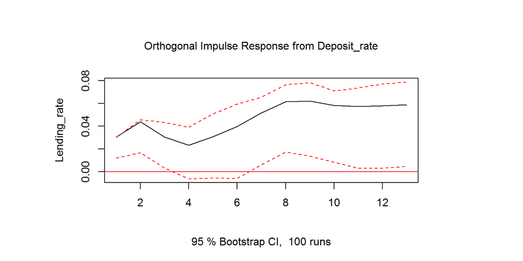

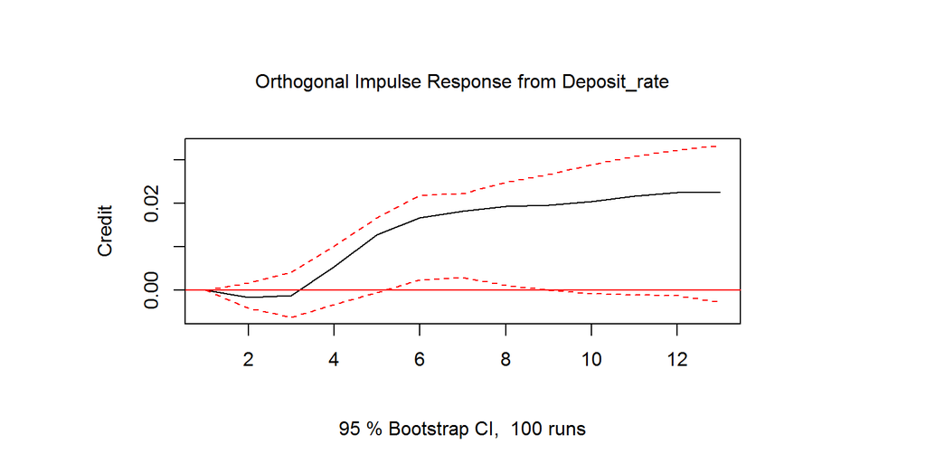

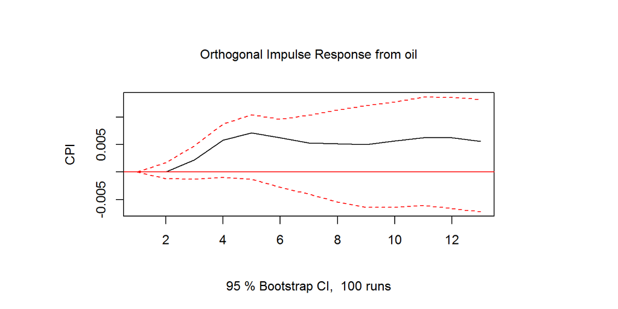